# Is asteroid (10424) Gaillard a binary asteroid?

JF Gout

1/27/2024

## 1. Parameters of the predicted occultation.

On January 14th 2024, shortly after 6am (UTC - that’s midnight local time in Mississippi), I observed an occultation of the magnitude 12.95 (Gaia G) star **UCAC4 558-046959** by the asteroid **(10424) Gaillard**. The prediction from OccultWatcher was a 76.6% to observe an occultation from my location with a predicted magnitude drop of 5.0.

Asteroid (10424) Gaillard has an estimated diameter of 6.563 km (my understanding is that this comes from assuming a spherical shape with an average albedo and using the magnitude to back calculate the size, but I’d be happy to learn more about this). At that time, the asteroid was 1.2936 AU away from Earth (193 million km or about 1.7 billion football fields in US units) which means that its angular diameter would be ~0.007“. With the asteroid travelling accross the sky at 0.64” per minute of time, the maximum duration predicted by OccultWatcher was 0.7 seconds.

The occulted star being of magnitude ~13. I had to use a fairly long exposure time (90ms) and crank up the gain a lot (95%) on my camera (ASI533MM mounted on an 11-inch SCT telescope: C11 edgehd with Hyperstar V4 resulting in a sampling of 1.44" per pixel). This resulted in a noisy recording, but it was my only option to record a reasonable number of frames for this occultation.

## 2. The video and preliminary analysis.

Let’s start with an annotated still frame showing the target star:

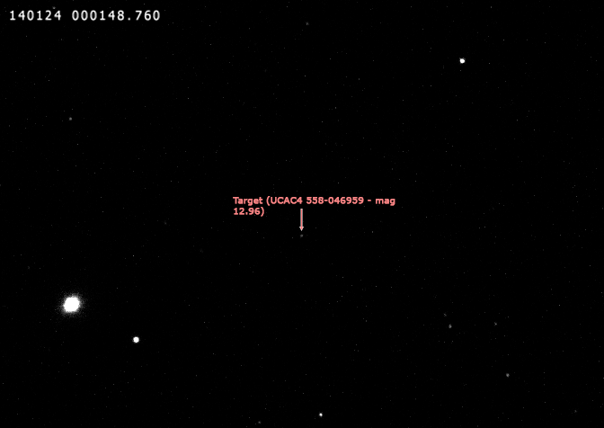

Frame with target

And a short GIF showing (on a loop) the moment of the occultation (slowed down relative to real time - note that the time stamps are in local time for Starkville, MS):

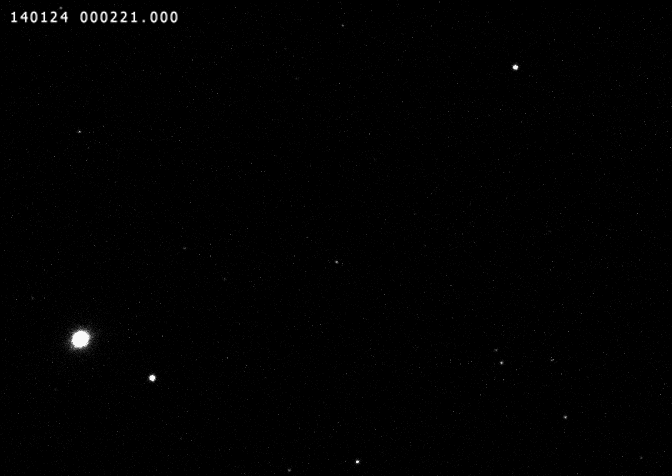

Annimated GIF

As you can see, there is a lot of noise (lots of pixels randomly turning ON and OFF) because of the extremely high gain (= amplification) setting on the camera. Yet, it is clear that the target star disapears a first time (for about 0.42 seconds), reappears for about 0.3 seconds and then disapears again for about 0.26 seconds.

To make it easier to see, here is the light curve, for the target, produced by PyMovie (zoomed in on the time of the occultation, the full csv file is available here: csv file)

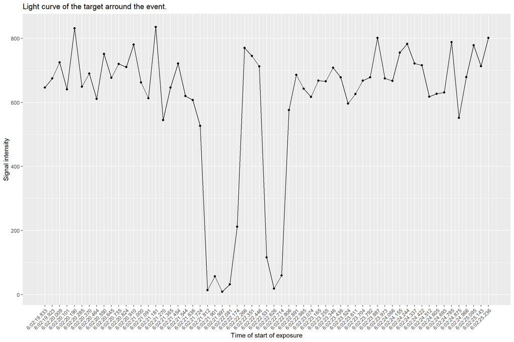

It is clear from the light curve that there were two occultations. But what caused this double occultation?

## 3. Binary asteroid or binary star?

If we exclude the odd event (an “occultation” by a bird/flying object/satellite just before/after the actual occultation by the asteroid), there are two possible explanations for this light curve:

1. The occulted star is actually a close binary (separated by ~7 milliarcseconds based on ~0.72 seconds of time between the start of each event and the asteroid moving at 0.64 arcseconds per minute of time - this is less than the resolving power of all big surveys).
2. The occulting asteroid is a binary asteroid (or has a really strange shape resulting in two parts of the asteroid occulting with a gap in-between - I will treat this as the same hypothesis as a binary asteroid for the moment)

Here is how we can test these two hypotheses: in the case of a binary star, the light from one of the two stars should always be visible. However, in the case of a binary asteroid, the only light left is that of the asteroid, which was estimated to be at magnitude 18. So, how deep did the signal go during the events? That’s difficult to say precisely because it went deep enough to be indistinguishable from the background noise (more on that later).

So, how low could the signal have gone in the case of a binary star? If one member of the system is very dim (say, 15.0 for example), the other star has to be fairly bright (magnitude 13.14 in this example, so that the two sum to magnitude 12.96). Under that scenario, signal from the bright star would still be visible when the asteroid was occulting the dim star. The “worse case scenario” is if both stars are of the same magnitude. That’s when the maximum amount of signal from any two events would be at the lowest possible. Under this scenario, the amount of signal from the target during each of the two events would be half that of the signal outside of the events, or about 350 (in summed ADUs from PyMovie, which is what you see on the Y axis of the light curve).

The average value of the signal for the target is 696.2 (sd: 66.8, min = 488 and max = 970). This next graph shows a wider portion of the light curve to illustrate the variation in signal intensity:

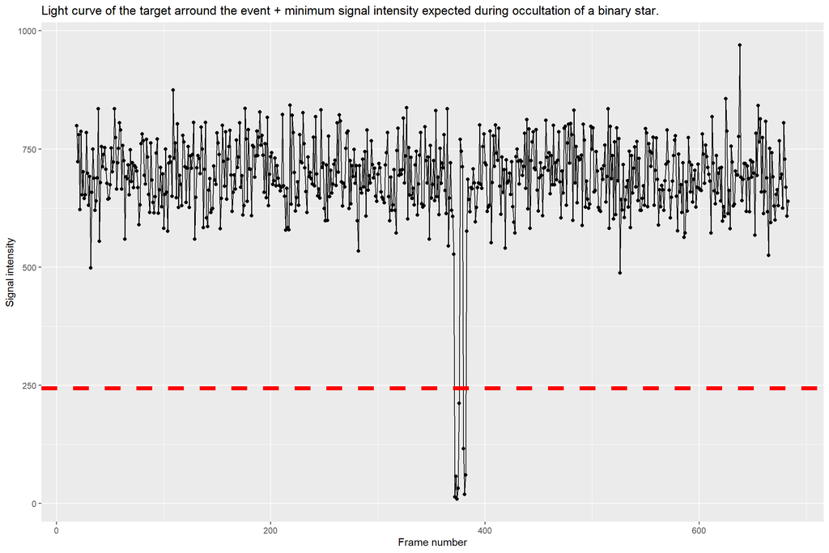

```r
# Excluding the frames with the GSP flash
endFirstFlash <- 18
startSecondFlash <- 684
tBetweenFlashes <- t[which(t$FrameNum>endFirstFlash & t$FrameNum<startSecondFlash) , ]

gp <- ggplot(tBetweenFlashes, aes(x = FrameNum, y = signal.target.558.046959)) +
      geom_point() +
      geom_line() +
  geom_hline(yintercept = targetMin/2, linetype="dashed", color = "red", size=2) +
      ylab("Signal intensity") +
      xlab("Frame number") +
      ggtitle("Light curve of the target arround the event + minimum signal intensity expected during occultation of a binary star.")

plot(gp)
```

The variation in signal intensity comes from a number of sources, including atmospheric scintillation, instrumental turbulence, electronic noise (= all sorts of noise generated by the camera), etc. While it would be nice to have less noise, it is clear that even for the lowest value of signal (488 - out of 751 frames), half the value (244 which is what we would expect for a binary star system with two components of equal magnitude and shown as a dashed red line in the graph above) is clearly well above the signal that we observe during each of the two events.

### A more in-depth look at the binary star hypothesis.

Playing the devil’s advocate, one might argue that the response curve of the CMOS camera used here (ASI533MM) is not perfectly linear and that it might have failed to pick up the signal from a star half as bright as the out-of-occultation target. To test this hypothesis, I’ve measured (in PyMovie) the signal from a couple of faint stars (magnitude 13.94 UCAC4 558-046950 and magnitude 14.73 UCAC4 559-046439). I also measured the amoint of background noise by placing an aperture of similar size (6 pixels radius -> 30 pixels in the mask) on a random positions away from any visible star.

Keep in mind that two stars of equal magnitude would have to be magnitude 13.71 each to combine into one target of magnidue 12.96. In other words, UCAC4 558-046950 (magnitude 13.94) is fairly close to the amount of signal expected during each event for such a binary system and UCAC4 559-046439 (magnitude 14.73) a full magnitude fainter.

Here are the light curves:

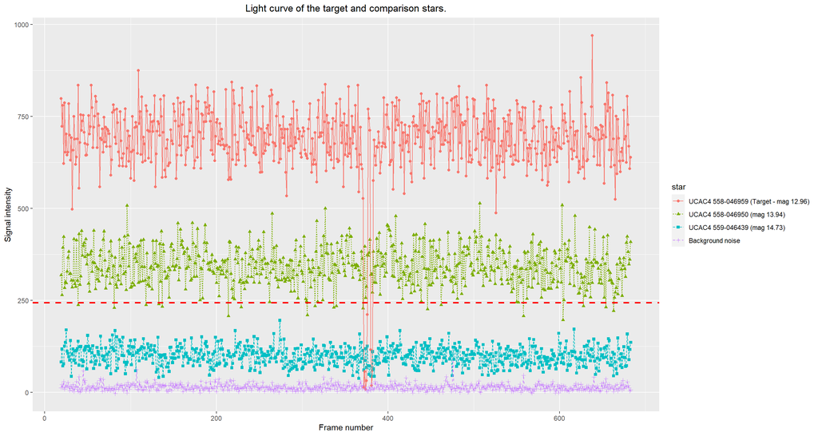

And the same thing, but zoomed in on the time of the occultation(s):

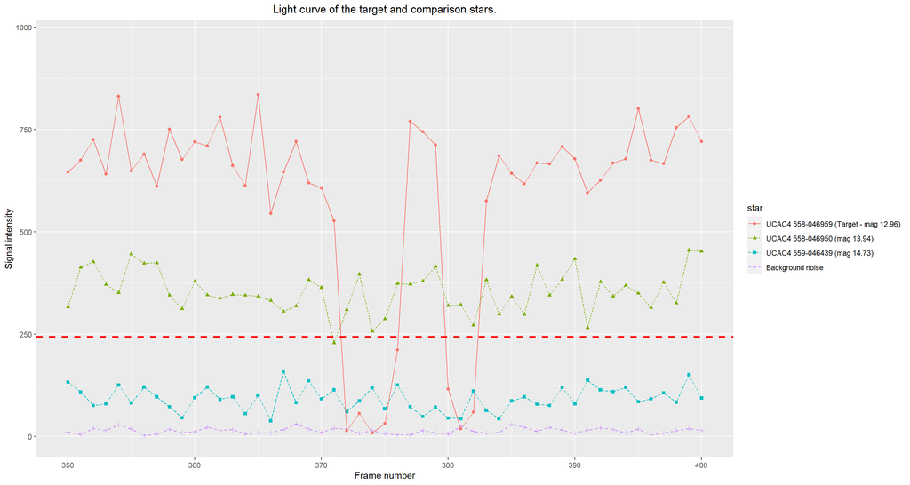

We can clearly see that the signal for the target stars goes well below that of a magnitude 13.94 star during both events, and it is even less than the signal from a magnitude 14.73 star (but not different from the background signal). Here are the numbers to support this visual examination:

The lowest signal for the target was: **9** during the first event and **19** during the second event.

The average signal for the background noise was 14.6 (sd: 9.7 - min: -3 and max: 89). Note that the few abnormally high values for the background noise probably come from hot pixels lighting up randomly.

These numbers confirm that, for both events, the signal for the target drops to levels statistically indistinguishable from the background noise.

Visually, it is obvious that the signal drops well below the minimum ever observed for the magnitude 13.94 star (that value is 197 for the curious ones out there).

What about the magnitude 14.73 star? The average signal for this star was 100.4 (sd: 25.7) with min: 38 and max: 196)

Because the signal for the magnitude 14.73 star never drops as low as that of the target during the two events (out of 751 frames), we can conclude that the signal for the target drops to a value significantly lower than magnitude 14.73 in both events. That is about one full magnitude lower than the magnitude drop expected in the worse case scenario of a binary system made of two mag 13.71 stars. Therefore, we can safely reject the binary star hypothesis!

## 4. Characteristics of the binary asteroid.

Having rejected the binary star hypothesis, let’s look at what the light curve tells us about the physical characteristics of this potential binary asteroid. To do so, we need to establish the precise timing of each event. Below is a zoomed-in light curve centered around the occultation(s) and with time stamps showing the start of each frame (remember, each frame is 90ms exposure):

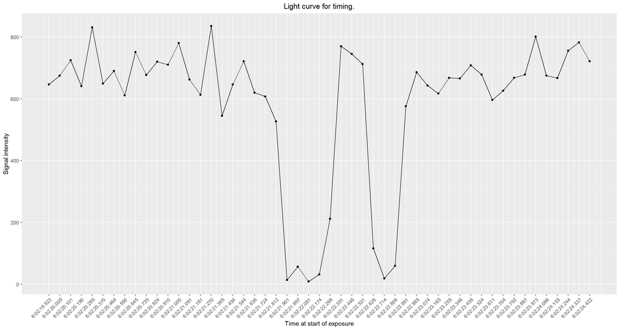

Although the PyOTE software is capable of finding start/end times of occultations, I like to check things by hand. Here is the reasoning for both events:

### First event:

It is obvious that the occultation was ongoing during the frame started at 6:02:21.901. We need to answer two questions: could it have started earlier? What fraction of this frame happened during the occulted time? The previous frame has a signal value of 527. This is lower than the average value for the target (696), lower than the average minus sd (696 - 67 = 629), but still within the range of values for the target outside of the occultation(s) (minimum = 488). Therefore, we cannot fully exclude that the occultation started only after 6:02:21.901, but the most parsimonious scenario is that the previous frame (starting at 6:02:21.812 capture a small amount of the occultation, based on its signal intensity being lower than the average minus sd). Therefore, the most likely start time of the first event would be: 6:02:21.812 + (527/696)*0.09 = 6:02:21.880 (remember, the average signal and the duration of each frame is 90ms).

Using the sd (67) of the average signal (696) for the target to derive a confidence interval for the start of the first occultation, we obtain:  
Lower confidence interval = 6:02:21.812 + (527/(696+67))*0.09 = 6:02:21.874 Upper confidence interval = 6:02:21.812 + (527/(696-67))*0.09 = 6:02:21.887

**Start of first event: 6:02:21.880 [CI: 6:02:21.874 - 6:02:21.887]**

The end of the first event is clearly captured by the frame starting at 6:02:22.266 (the signal intensity level of 212 clearly indicates that some signal from the star was present in this frame).  
Following the same logic, the most likely time of end for the first event is: 6:02:22.266 + ((696-212)/696)*0.09 = 6:02:22.329

And the confidence interval:

Min = 6:02:22.266 + ((696-212)/(696+67))0.09 = 6:02:22.323  
Max = 6:02:22.266 + ((696-212)/(696-67))0.09 = 6:02:22.335

**End of first event: 6:02:22.329 [CI: 6:02:22.323 - 6:02:22.335]**

Therefore, we have: **Duration of the first event: 0.449 seconds [CI: 0.436 - 0.461]**

### Second event:

For the second event, the frame starting at 6:02:22.626 has a signal intensity value of 116, suggesting a start of the second event at: 6:02:22.626 + (116/696)*0.09 = 6:02:22.641

And the confidence interval:

Min = 6:02:22.626 + (116/(696+67))*0.09 = 6:02:22.640

Max = 6:02:22.626 + (116/(696-67))*0.09 = 6:02:22.643

**Start of second event: 6:02:22.641 [CI: 6:02:22.640 - 6:02:22.643]**

For the end of the second event, the last frame (starting at 6:02:22.891) has a signal intensity of 576, which is slightly lower than average minus sd. Therefore, I’ll go with the hypothesis that a small fraction of this frame took place while the occultation was still ongoing, giving us an expected time of end for the second event of: 6:02:22.891 + ((696-576)/696)*0.09 = 6:02:22.906

Min = 6:02:22.891 + ((629-576)/629)*0.09 = 6:02:22.899

Max = 6:02:22.891 + ((763-576)/763)*0.09 = 6:02:22.913

**End of the second event: 6:02:22.906 [CI: 6:02:22.899 - 6:02:22.913]**

Therefore, we have a **duration for the second event of: 0.266 seconds [CI: 0.256 - 0.273]**

Note that my strategy for computing times and confidence intervals might not be the most refined startegy possible, but I doubt the results would change significantly by applying any other strategy.

## Conclusion.

This occultation produced two events, of 0.449 and 0.266 seconds each, for a total of 0.715 seconds [CI: 0.692 - 0.734], which fits nicely with the 0.7 maximum duration predicted by OccultWatcher. This suggests that the entire width of the asteroid was sampled and makes the hypothesis of a grazing occultation with a convoluted shape unlikely.

## A final note on the precision of time stamps.

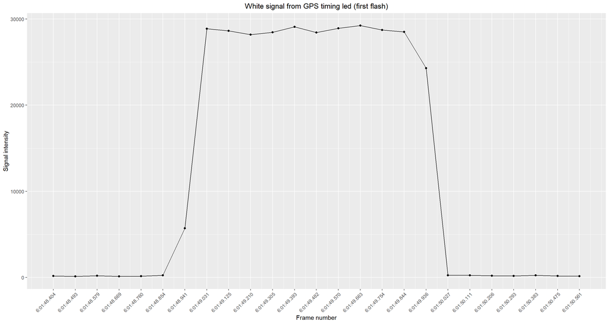

Using the same stratgey as above, and knowing that the average signal for the white signal during the flahs was 28,706 and that the signal for the frame starting at 6:01:48.941 was 5,702 we can estimate the start of the flash at: 6:01:48.941 + ( (28706-5702)/28706)*0.09 = 6:01:49.013

That would be 13 milliseconds after the LED actually started lighting up.

The end of the flash would have been timed at: 6:01:49.936 + (24300/28706)*0.09 = 6:01:50.012 (almost the same offset: 12ms)

Looking at the second flash:

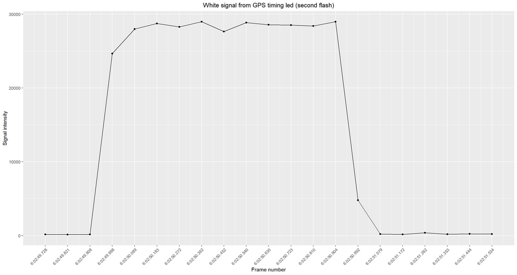

Start: 6:02:49.998 + ( (28489-24661)/28489 )*0.09 = 6:02:50.010

End: 6:02:50.992 + (4785/28489)*0.09 = 6:02:51.007

Therefore, it appears that my timings are off by about 10 milliseconds. While it would be nice to have more accurate timing, this small clock drift does not change the main conclusions of this analysis.